# credit_card_fraud

## **CREDIT CARD FRAUD DETECTION**

This project focusses on fraud detection based on a dataset that consists of credit card transaction details. The dataset consists of pre-labelled column to indicate if the transaction was a fraud or not. The columns in the dataset are scaled except for the columns 'Time' and 'Amount' due to security reasons. All the scaled columns are named after 'V' where each column indicates a feature of the transaction.

### Group 7 Team Members

- Praiselin Lydia Gladston
- Yakub Yekini

### **IMPORTING REQUIRED LIBRARIES**

```python
import numpy as np
import pandas as pd
```

```python
import matplotlib.pyplot as plt
%matplotlib inline
import seaborn as sns
```

```python
from sklearn.model_selection import train_test_split
from sklearn.linear_model import LogisticRegression
from sklearn.neighbors import KNeighborsClassifier
from sklearn.ensemble import RandomForestClassifier
```

```python
from sklearn.model_selection  import cross_val_score
```

```python
from sklearn.metrics import roc_curve
from sklearn.metrics import roc_auc_score
```

```python
import warnings
warnings.filterwarnings("ignore")
```

### **EXPLORATORY ANALYSIS**

```python
df = pd.read_csv('creditcard.csv')
df.head(10)
```

|  | Time | V1 | V2 | V3 | V4 | V5 | V6 | V7 | V8 | V9 | ... | V21 | V22 | V23 | V24 | V25 | V26 | V27 | V28 | Amount | Class |
| --- | --- | --- | --- | --- | --- | --- | --- | --- | --- | --- | --- | --- | --- | --- | --- | --- | --- | --- | --- | --- | --- |
| 0 | 0.0 | -1.359807 | -0.072781 | 2.536347 | 1.378155 | -0.338321 | 0.462388 | 0.239599 | 0.098698 | 0.363787 | ... | -0.018307 | 0.277838 | -0.110474 | 0.066928 | 0.128539 | -0.189115 | 0.133558 | -0.021053 | 149.62 | 0 |
| 1 | 0.0 | 1.191857 | 0.266151 | 0.166480 | 0.448154 | 0.060018 | -0.082361 | -0.078803 | 0.085102 | -0.255425 | ... | -0.225775 | -0.638672 | 0.101288 | -0.339846 | 0.167170 | 0.125895 | -0.008983 | 0.014724 | 2.69 | 0 |
| 2 | 1.0 | -1.358354 | -1.340163 | 1.773209 | 0.379780 | -0.503198 | 1.800499 | 0.791461 | 0.247676 | -1.514654 | ... | 0.247998 | 0.771679 | 0.909412 | -0.689281 | -0.327642 | -0.139097 | -0.055353 | -0.059752 | 378.66 | 0 |
| 3 | 1.0 | -0.966272 | -0.185226 | 1.792993 | -0.863291 | -0.010309 | 1.247203 | 0.237609 | 0.377436 | -1.387024 | ... | -0.108300 | 0.005274 | -0.190321 | -1.175575 | 0.647376 | -0.221929 | 0.062723 | 0.061458 | 123.50 | 0 |
| 4 | 2.0 | -1.158233 | 0.877737 | 1.548718 | 0.403034 | -0.407193 | 0.095921 | 0.592941 | -0.270533 | 0.817739 | ... | -0.009431 | 0.798278 | -0.137458 | 0.141267 | -0.206010 | 0.502292 | 0.219422 | 0.215153 | 69.99 | 0 |
| 5 | 2.0 | -0.425966 | 0.960523 | 1.141109 | -0.168252 | 0.420987 | -0.029728 | 0.476201 | 0.260314 | -0.568671 | ... | -0.208254 | -0.559825 | -0.026398 | -0.371427 | -0.232794 | 0.105915 | 0.253844 | 0.081080 | 3.67 | 0 |
| 6 | 4.0 | 1.229658 | 0.141004 | 0.045371 | 1.202613 | 0.191881 | 0.272708 | -0.005159 | 0.081213 | 0.464960 | ... | -0.167716 | -0.270710 | -0.154104 | -0.780055 | 0.750137 | -0.257237 | 0.034507 | 0.005168 | 4.99 | 0 |
| 7 | 7.0 | -0.644269 | 1.417964 | 1.074380 | -0.492199 | 0.948934 | 0.428118 | 1.120631 | -3.807864 | 0.615375 | ... | 1.943465 | -1.015455 | 0.057504 | -0.649709 | -0.415267 | -0.051634 | -1.206921 | -1.085339 | 40.80 | 0 |
| 8 | 7.0 | -0.894286 | 0.286157 | -0.113192 | -0.271526 | 2.669599 | 3.721818 | 0.370145 | 0.851084 | -0.392048 | ... | -0.073425 | -0.268092 | -0.204233 | 1.011592 | 0.373205 | -0.384157 | 0.011747 | 0.142404 | 93.20 | 0 |
| 9 | 9.0 | -0.338262 | 1.119593 | 1.044367 | -0.222187 | 0.499361 | -0.246761 | 0.651583 | 0.069539 | -0.736727 | ... | -0.246914 | -0.633753 | -0.120794 | -0.385050 | -0.069733 | 0.094199 | 0.246219 | 0.083076 | 3.68 | 0 |

10 rows × 31 columns

The data indicates what was previously informed. All the features except Time and Amount are scaled. The description of the data says that all the features went through PCA transformation.

```python
df.info()
```

```
<class 'pandas.core.frame.DataFrame'>
RangeIndex: 284807 entries, 0 to 284806
Data columns (total 31 columns):
 #   Column  Non-Null Count   Dtype
---  ------  --------------   -----
 0   Time    284807 non-null  float64
 1   V1      284807 non-null  float64
 2   V2      284807 non-null  float64
 3   V3      284807 non-null  float64
 4   V4      284807 non-null  float64
 5   V5      284807 non-null  float64
 6   V6      284807 non-null  float64
 7   V7      284807 non-null  float64
 8   V8      284807 non-null  float64
 9   V9      284807 non-null  float64
```

[output cut: 23 more lines]

```python
has_nulls = df.isnull().values.any()
print(has_nulls)
```

```
False
```

From the above information, there are 31 columns to the dataset. There are no null values in the dataset, which means that the dataset does not require any transformation or cleaning. For visual understanding of the data, we will label the Class column as 'Fraud' and 'Non_Fraud' transaction.

```python
df['Class_Desc'] = df['Class'].astype('category')
df['Class_Desc'] = df['Class_Desc'].cat.rename_categories({1:'Fraud',0:'Non_Fraud'})
df['Class_Desc']
```

```
0         Non_Fraud
1         Non_Fraud
2         Non_Fraud
3         Non_Fraud
4         Non_Fraud
            ...
284802    Non_Fraud
284803    Non_Fraud
284804    Non_Fraud
284805    Non_Fraud
284806    Non_Fraud
Name: Class_Desc, Length: 284807, dtype: category
Categories (2, object): ['Non_Fraud', 'Fraud']
```

```python
classes = df['Class_Desc'].value_counts()
normal_share = classes[0]/df['Class'].count() * 100
print(normal_share)
fraud_share = classes[1]/df['Class'].count() * 100
print(fraud_share)

class_dist = {'Class':['fraud','non_fraud'],'Percentage':[fraud_share, normal_share]}
class_dist = pd.DataFrame(class_dist)
class_dist.head()
```

```
99.82725143693798
0.1727485630620034
```

|  | Class | Percentage |
| --- | --- | --- |
| 0 | fraud | 0.172749 |
| 1 | non_fraud | 99.827251 |

While observing the count of data from each class, we could see that the dataset is heavily imbalanced. The data has 99.83% of valid payments and just 0.17% of fraud transactions. This kind of dataset could result in a overfitted model that will decide that most of the transactions are not fraudulent.

Since the only 2 columns that still have understandable data is the Time and Amount, we will see the distribution of both the columns with respect to both fraudulent and valid payments. A valid assumption here would be that fraudulent transactions will have higher value for 'Amount' column since a fraud might try to make use of the situation to the best. We will explore on that idea further.

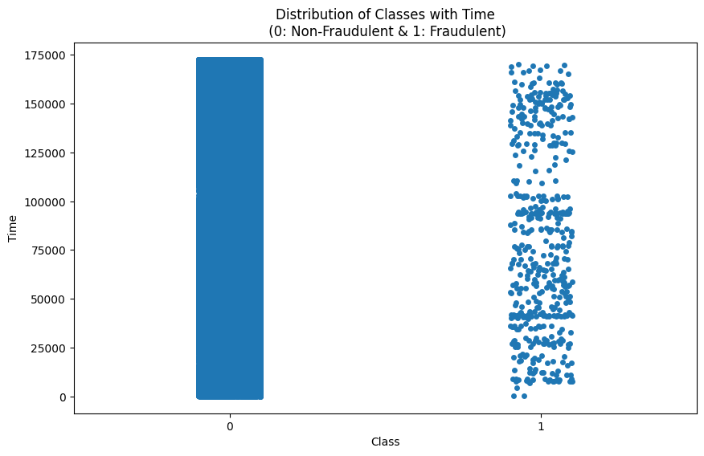

```python
plt.figure(figsize=(10,6))
sns.stripplot(x= 'Class', y= 'Time',data=df)
plt.title('Distribution of Classes with Time\n (0: Non-Fraudulent & 1: Fraudulent)')
plt.show()
```

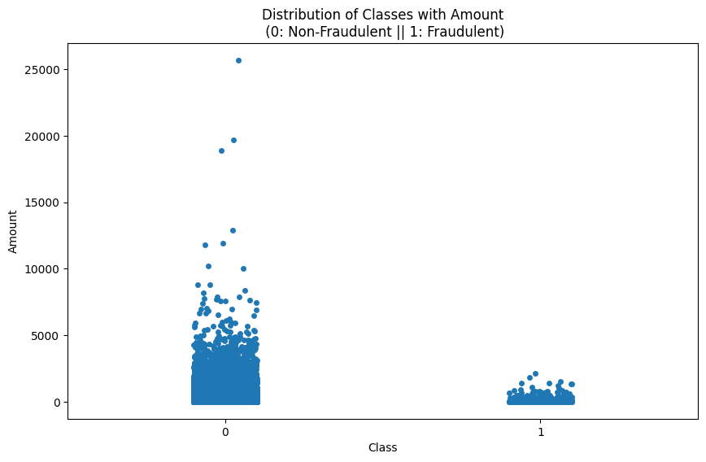

```python
plt.figure(figsize=(10,6))
sns.stripplot(x= 'Class', y= 'Amount', data=df)
plt.title('Distribution of Classes with Amount\n (0: Non-Fraudulent || 1: Fraudulent)')
plt.show()
```

Based on the two distributions, we could not conclude that these 2 columns will be helpful in judging the status of the transaction. The 'Amount' distribution is contradictory to our assumption since all of the fraud transactions recorded in the dataset have amount less than 2500 whereas there are transactions that have amount go over 25000.

The Time column is almost uniformly distributed for both the classes. Which makes it the lesser deciding factor.

We will look at the correlation matrix of the available data to see which features are highly correlated to each other.

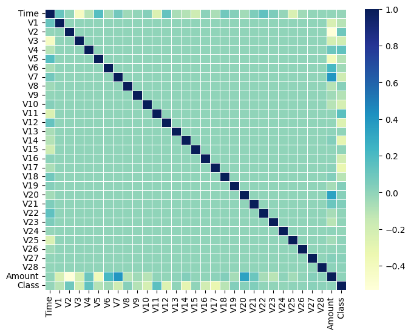

```python
plt.figure(figsize=(8,6))
sns.heatmap(df.iloc[:, :31].corr(),linewidths=0.5,cmap='YlGnBu')
plt.show()
```

### **BALANCING DATASET**

Using [this Kaggle Notebook](https://www.kaggle.com/code/janiobachmann/credit-fraud-dealing-with-imbalanced-datasets) as reference, we are trying to balance out the dataset, to avoid overfitting, by sampling the minority data. The technique will provide us with a balanced ratio of fraud and non-fraud transactions.

```python
classes
```

```
Class_Desc
Non_Fraud    284315
Fraud           492
Name: count, dtype: int64
```

There are just 492 fraud transactions whereas there are 284315 non-fraud transactions. This shows that the data is very skewed. We will proceed with using SMOTE (Synthetic Minority Over-sampling Technique) to balance the classes.

```python
df = df.drop('Class_Desc', axis=1)
X = df.drop('Class', axis=1)
y = df['Class']
```

We will split 20% of the data and maintain it as the validation set separately. At the end of model training and testing, we will validate our best model to check for model accuracy. The rest of the 80%, we will use to sample using SMOTE and generate the training and test dataset.

```python
X_data, X_val, y_data, y_val = train_test_split(X, y, test_size=0.2, random_state=42)
```

```python
from imblearn.over_sampling import SMOTE

smote = SMOTE()
X_resampled, y_resampled = smote.fit_resample(X_data, y_data)

new_df = pd.DataFrame(X_resampled, columns=X.columns)
new_df['Class'] = y_resampled
```

Now that we have balanced the classes in the data, we will have a peek at the correlation matrix.

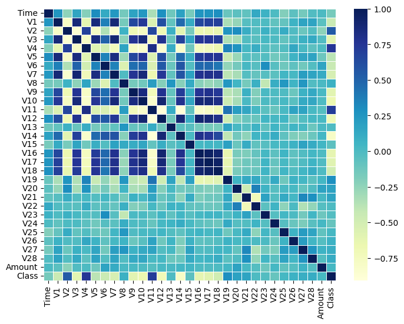

```python
plt.figure(figsize=(8,6))
sns.heatmap(new_df.iloc[:, :31].corr(),linewidths=0.5,cmap='YlGnBu')
plt.show()
```

We could see the difference in the correlation matrix after balancing the data. The features V2, V4, V8, V11, V13, V15, V19 - V28 are all more positively correlated to the target variable while features V10, V12, V14 are more negatively correlated.

### **OUTLIER REMOVAL**

It is crucial to remove extreme outliers to have high accuracy in prediction. Proceeding to remove outliers using Interquartile Range (Boxplot) technique. We are choosing V4, V11, V14 which seem to have high correlation with the target variable.

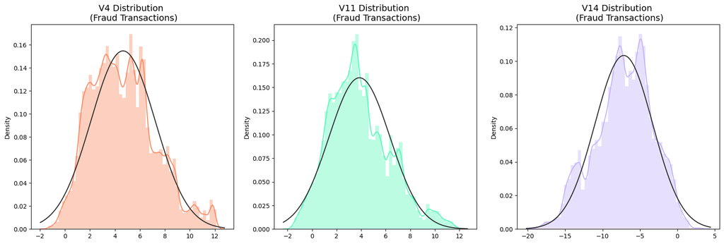

```python
from scipy.stats import norm

f, (ax1, ax2, ax3) = plt.subplots(1,3, figsize=(20, 6))

v4_fraud_dist = new_df['V4'].loc[new_df['Class'] == 1].values
sns.distplot(v4_fraud_dist,ax=ax1, fit=norm, color='#FB8861')
ax1.set_title('V4 Distribution \n (Fraud Transactions)', fontsize=14)

v11_fraud_dist = new_df['V11'].loc[new_df['Class'] == 1].values
sns.distplot(v11_fraud_dist,ax=ax2, fit=norm, color='#56F9BB')
ax2.set_title('V11 Distribution \n (Fraud Transactions)', fontsize=14)


v14_fraud_dist = new_df['V14'].loc[new_df['Class'] == 1].values
sns.distplot(v14_fraud_dist,ax=ax3, fit=norm, color='#C5B3F9')
ax3.set_title('V14 Distribution \n (Fraud Transactions)', fontsize=14)

plt.show()
```

Removing outliers from V4:

```python
v4_fraud = new_df['V4'].loc[new_df['Class'] == 1].values
q25, q75 = np.percentile(v4_fraud, 25), np.percentile(v4_fraud, 75)
print('Quartile 25: {} | Quartile 75: {}'.format(q25, q75))
v4_iqr = q75 - q25
print('iqr: {}'.format(v4_iqr))
```

```
Quartile 25: 2.692973980773666 | Quartile 75: 6.24466044419114
iqr: 3.5516864634174743
```

```python
v4_cut_off = v4_iqr * 1.5
v4_lower, v4_upper = q25 - v4_cut_off, q75 + v4_cut_off
print('Cut Off: {}'.format(v4_cut_off))
print('V4 Lower: {}'.format(v4_lower))
print('V4 Upper: {}'.format(v4_upper))
```

```
Cut Off: 5.327529695126211
V4 Lower: -2.634555714352545
V4 Upper: 11.572190139317351
```

```python
outliers = [x for x in v4_fraud if x < v4_lower or x > v4_upper]
print('Feature V4 Outliers for Fraud Cases: {}'.format(len(outliers)))

new_df = new_df.drop(new_df[(new_df['V4'] > v4_upper) | (new_df['V4'] < v4_lower)].index)
```

```
Feature V4 Outliers for Fraud Cases: 2608
```

Removing outliers from V11:

```python
v11_fraud = new_df['V11'].loc[new_df['Class'] == 1].values
q25, q75 = np.percentile(v11_fraud, 25), np.percentile(v11_fraud, 75)
v11_iqr = q75 - q25

v11_cut_off = v11_iqr * 1.5
v11_lower, v11_upper = q25 - v11_cut_off, q75 + v11_cut_off
print('Cut Off: {}'.format(v4_cut_off))
print('V11 Lower: {}'.format(v11_lower))
print('V11 Upper: {}'.format(v11_upper))

outliers = [x for x in v11_fraud if x < v11_lower or x > v11_upper]
print('V11 outliers: {}'.format(outliers))
print('Feature V11 Outliers for Fraud Cases: {}'.format(len(outliers)))
new_df = new_df.drop(new_df[(new_df['V11'] > v11_upper) | (new_df['V11'] < v11_lower)].index)
print('Number of Instances after outliers removal: {}'.format(len(new_df)))
```

```
Cut Off: 5.327529695126211
V11 Lower: -2.9107887784651445
V11 Upper: 10.290776670804696
V11 outliers: [10.8530116481991, 10.5452629545898, 12.0189131816199, 11.6692047358121, 11.1524905985837, 11.2779207278067, 11.0270590938161, 10.446846814514, 10.529709909771567, 10.723462488654071, 10.609788439583157, 11.025893879625695, 10.354264331665316, 11.221412506917524, 11.274138788509884, 11…
Feature V11 Outliers for Fraud Cases: 2900
Number of Instances after outliers removal: 443700
```

Removing outliers for V14:

```python
v14_fraud = new_df['V14'].loc[new_df['Class'] == 1].values
q25, q75 = np.percentile(v14_fraud, 25), np.percentile(v14_fraud, 75)
v14_iqr = q75 - q25

v14_cut_off = v14_iqr * 1.5
v14_lower, v14_upper = q25 - v14_cut_off, q75 + v14_cut_off
print('Cut Off: {}'.format(v4_cut_off))
print('V14 Lower: {}'.format(v14_lower))
print('V14 Upper: {}'.format(v14_upper))

outliers = [x for x in v14_fraud if x < v14_lower or x > v14_upper]
print('V14 outliers: {}'.format(outliers))
print('Feature V14 Outliers for Fraud Cases: {}'.format(len(outliers)))
new_df = new_df.drop(new_df[(new_df['V14'] > v14_upper) | (new_df['V14'] < v14_lower)].index)
print('Number of Instances after outliers removal: {}'.format(len(new_df)))
```

```
Cut Off: 5.327529695126211
V14 Lower: -16.697046580823578
V14 Upper: 2.9461013082298377
V14 outliers: [3.44242199594215, -17.6206343516773, -17.181909117120995, -16.824423042485066, -16.985602152103805, 3.3093559966793387, -17.06971735157346, 3.0575089525695645, -17.322361887704737, -17.13590275219058, -16.769668749761788, -17.52744996097319, -16.699638833440257, 3.2599810999770265, -1…
Feature V14 Outliers for Fraud Cases: 320
Number of Instances after outliers removal: 442928
```

Now after removal of outliers, lets look at the distribution.

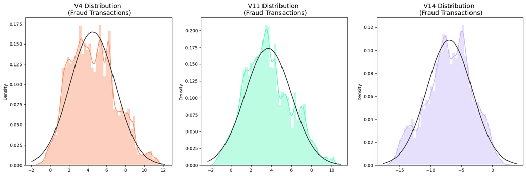

```python
f, (ax1, ax2, ax3) = plt.subplots(1,3, figsize=(20, 6))

v4_fraud_dist = new_df['V4'].loc[new_df['Class'] == 1].values
sns.distplot(v4_fraud_dist,ax=ax1, fit=norm, color='#FB8861')
ax1.set_title('V4 Distribution \n (Fraud Transactions)', fontsize=14)

v11_fraud_dist = new_df['V11'].loc[new_df['Class'] == 1].values
sns.distplot(v11_fraud_dist,ax=ax2, fit=norm, color='#56F9BB')
ax2.set_title('V11 Distribution \n (Fraud Transactions)', fontsize=14)


v14_fraud_dist = new_df['V14'].loc[new_df['Class'] == 1].values
sns.distplot(v14_fraud_dist,ax=ax3, fit=norm, color='#C5B3F9')
ax3.set_title('V14 Distribution \n (Fraud Transactions)', fontsize=14)

plt.show()
```

The distribution has been fairly normalized after the removal of extreme outliers.

### **MODEL TRAINING**

We will split the data into training (80%) and test dataset (20%) and observe the training and cross validation score. The gap between the training and validation scores show how overfitted the model is.

```python
X = new_df.drop('Class', axis=1)
y = new_df['Class']
```

```python
X_train, X_test, y_train, y_test = train_test_split(X, y, test_size=0.2, random_state=42)
```

```python
X_train = X_train.values
X_test = X_test.values
y_train = y_train.values
y_test = y_test.values
```

We will experiment with 3 different classifiers and observe which performs the best.

```python
classifiers = {
    "LogisiticRegression": LogisticRegression(),
    "KNearest": KNeighborsClassifier(),
    "RandomForest": RandomForestClassifier()
}
```

```python
for key, classifier in classifiers.items():
    classifier.fit(X_train, y_train)
    training_score = cross_val_score(classifier, X_train, y_train, cv=5)
    print("Classifiers: ", classifier.__class__.__name__, "Has a training score of", round(training_score.mean(), 2) * 100, "% accuracy score")
```

```
Classifiers:  LogisticRegression Has a training score of 97.0 % accuracy score
Classifiers:  KNeighborsClassifier Has a training score of 95.0 % accuracy score
Classifiers:  RandomForestClassifier Has a training score of 100.0 % accuracy score
```

From the cross validation results, LogisticRegression and RandomForestClassifer performs the best. We will proceed to find the model performance parameter.

#### **Logistic Regression**

We will have a list of C values and obtain the best logistic regression model out of them.

```python
from sklearn.model_selection import GridSearchCV

log_reg_params = {"penalty": ['l1', 'l2'], 'C': [0.001, 0.01, 0.1, 1, 10, 100, 1000]}

grid_log_reg = GridSearchCV(LogisticRegression(), log_reg_params)
grid_log_reg.fit(X_train, y_train)

log_reg = grid_log_reg.best_estimator_
```

#### **Random Forest Classifier**

For random forest classifier, we will find the best 'max_depth' value and 'n_estimators'.

```python
from sklearn.model_selection import GridSearchCV

param = {'n_estimators': [10, 20, 30, 40, 50], 'max_depth': [2, 3, 4, 7, 9]}
rfc = RandomForestClassifier()
clf_rfc_cv = GridSearchCV(rfc, param, cv=5,scoring='roc_auc', n_jobs=-1)
clf_rfc_cv.fit(X_train,y_train)

print("tuned hpyerparameters :(best parameters) ",clf_rfc_cv.best_params_)
print("accuracy :",clf_rfc_cv.best_score_)
```

```
tuned hpyerparameters :(best parameters)  {'max_depth': 9, 'n_estimators': 50}
accuracy : 0.9995995652581329
```

```python
rf = RandomForestClassifier(max_depth=9, n_estimators=50)
rfc_clf = rf.fit(X_train,y_train)
```

We will obtain the prediction from both the classifiers for the training set and plot the roc curve to see their performance difference.

```python
from sklearn.model_selection import cross_val_predict

log_reg_pred = cross_val_predict(log_reg, X_train, y_train, cv=5, method="decision_function")
rfc_clf_prob = rfc_clf.predict_proba(X_train)
rfc_clf_prob = rfc_clf_prob[:, 1]

print('Logistic Regression ROC Score: ', roc_auc_score(y_train, log_reg_pred))
print('Random Forest Classifier ROC Score: ', roc_auc_score(y_train, rfc_clf_prob))
```

```
Logistic Regression ROC Score:  0.9913937811885926
Random Forest Classifier ROC Score:  0.9996109659946868
```

We could see that both the classifiers have ROC score for Logistic Regression is 0.991 and Random Forest Classifier is 0.999 where the latter performs a little better than the former and also has the best ROC score.

We will proceed to plotting the ROC curve to observe their performance.

```python
log_fpr, log_tpr, log_thresold = roc_curve(y_train, log_reg_pred)
rfc_fpr, rfc_tpr, rfc_threshold = roc_curve(y_train, rfc_clf_prob)
```

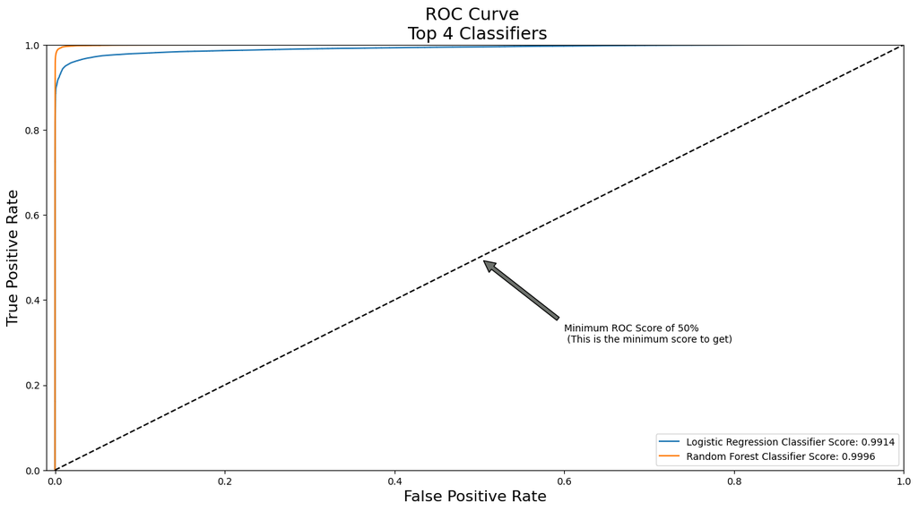

```python
def graph_roc_curve_multiple(log_fpr, log_tpr, rfc_fpr, rfc_tpr):
    plt.figure(figsize=(16,8))
    plt.title('ROC Curve \n Top 4 Classifiers', fontsize=18)
    plt.plot(log_fpr, log_tpr, label='Logistic Regression Classifier Score: {:.4f}'.format(roc_auc_score(y_train, log_reg_pred)))
    plt.plot(rfc_fpr, rfc_tpr, label='Random Forest Classifier Score: {:.4f}'.format(roc_auc_score(y_train, rfc_clf_prob)))
    plt.plot([0, 1], [0, 1], 'k--')
    plt.axis([-0.01, 1, 0, 1])
    plt.xlabel('False Positive Rate', fontsize=16)
    plt.ylabel('True Positive Rate', fontsize=16)
    plt.annotate('Minimum ROC Score of 50% \n (This is the minimum score to get)', xy=(0.5, 0.5), xytext=(0.6, 0.3),arrowprops=dict(facecolor='#6E726D', shrink=0.05),)
    plt.legend()

graph_roc_curve_multiple(log_fpr, log_tpr, rfc_fpr, rfc_tpr)
plt.show()
```

Both the classifiers have a similar ROC curve indicating both the models are almost equally performant.

### **MODEL VALIDATION**

Based on the ROC score, the Random Forest Classifier has the most ROC score and so we will select the model as our best model.

```python
y_test_pred = rfc_clf.predict(X_test)
```

#### Confusion Matrix

```python
from sklearn.metrics import confusion_matrix

rfc_cf = confusion_matrix(y_test, y_test_pred)
```

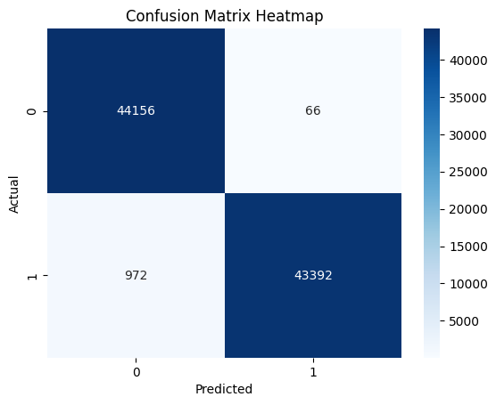

```python
sns.heatmap(rfc_cf, annot=True, fmt='d', cmap='Blues')
plt.xlabel('Predicted')
plt.ylabel('Actual')
plt.title('Confusion Matrix Heatmap')
plt.show()
```

```python
from sklearn.metrics import classification_report

y_val_pred = rfc_clf.predict(X_val)
class_report = classification_report(y_val, y_val_pred, digits=3)
print(class_report)
```

```
              precision    recall  f1-score   support

           0      1.000     0.999     0.999     56864
           1      0.537     0.888     0.669        98

    accuracy                          0.998     56962
   macro avg      0.768     0.943     0.834     56962
weighted avg      0.999     0.998     0.999     56962
```

The performance metrics suggest that the model has performed very well and has shows accuracy of 99.8%. The high accuracy is largely due to the overwhelming number of non-fraudulent transactions, which the model predicts very well. The precision value for fraud transactions is till low with 0.537. This requires investigation on the sampled dataset and can apply cost-sensitive approach to handle false positives and false negatives.